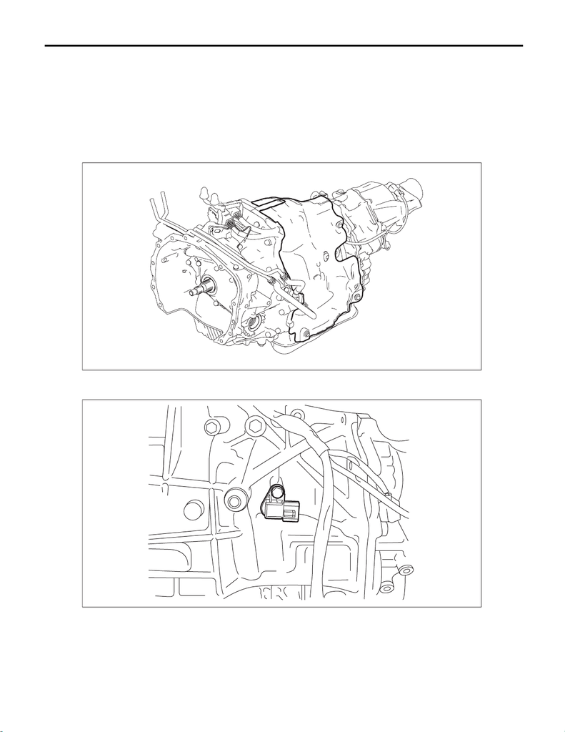

CVT(TR690)-99

Secondary Speed Sensor

CONTINUOUSLY VARIABLE TRANSMISSION

15.Secondary Speed Sensor

A: REMOVAL

CAUTION:

Be sure to prevent water or oil from contacting the connector terminal of secondary speed sensor. If

adhesion occurs, replace with a new part.

1) Remove the transmission from the vehicle. <Ref. to CVT(TR690)-56, REMOVAL, Automatic Transmission

Assembly.>

2) Remove the transmission cover on the transmission upper side.

3) Remove the secondary speed sensor harness connector.

4) Remove the secondary speed sensor.

CVT00499

AT-06554

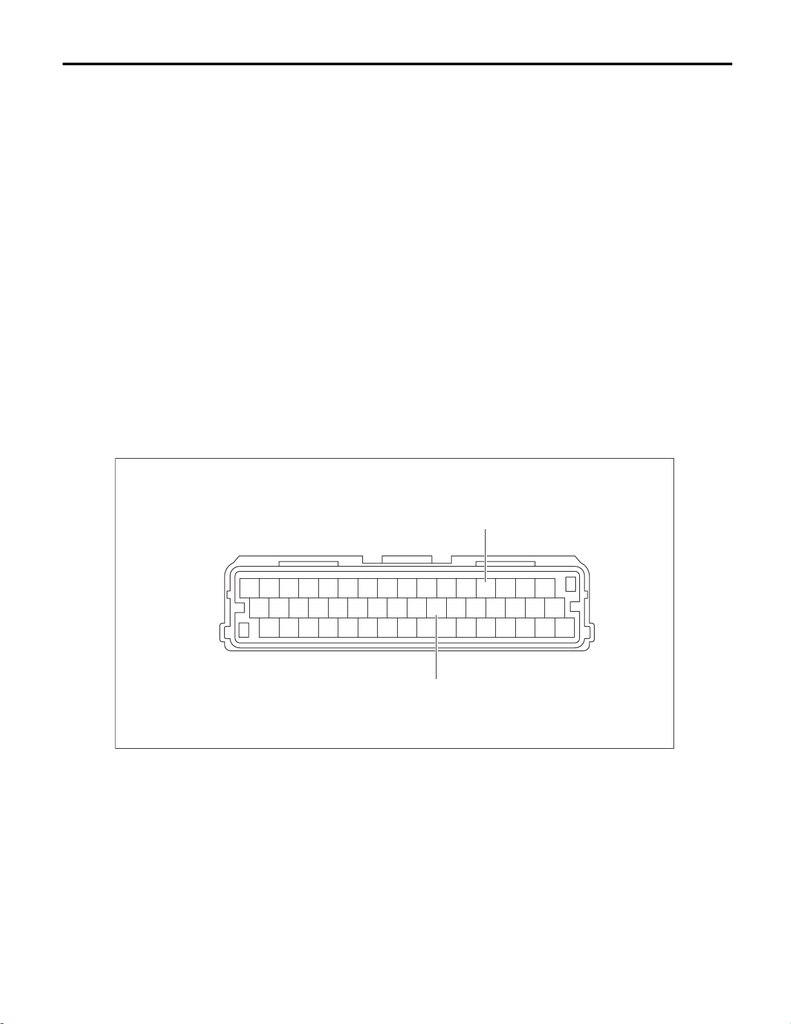

CVT(TR690)-100

Secondary Speed Sensor

CONTINUOUSLY VARIABLE TRANSMISSION

B: INSTALLATION

CAUTION:

Be sure to prevent water or oil from contacting the connector terminal of secondary speed sensor. If

adhesion occurs, replace with a new part.

Install in the reverse order of removal.

NOTE:

• Use new O-rings.

• Apply CVTF to the O-ring.

Tightening torque:

Secondary speed sensor

5 N·m (0.5 kgf-m, 3.7 ft-lb)

Transmission cover

8 N·m (0.8 kgf-m, 5.9 ft-lb)

C: INSPECTION

1) Remove the bulkhead harness connector from TCM. <Ref. to CVT(TR690)-126, REMOVAL, Transmis-

sion Control Module (TCM).>

2) Set the ST between the TCM and bulkhead harness.

ST 18460AA040 CHECK BOARD

3) Set the probe of oscilloscope to the check board connector.

Terminals:

No. 13 (+) — No. 26 (–)

(A) + probe

(B) – probe

123456789

10 11 12 13 14 15 16

17 18 19 20 21 22 23 24 25 26 27 28 29 30 31 32

33 34 35 36 37 38 39 40 41 42 43 44 45 46 47 48

(A)

(B)

CVT00510

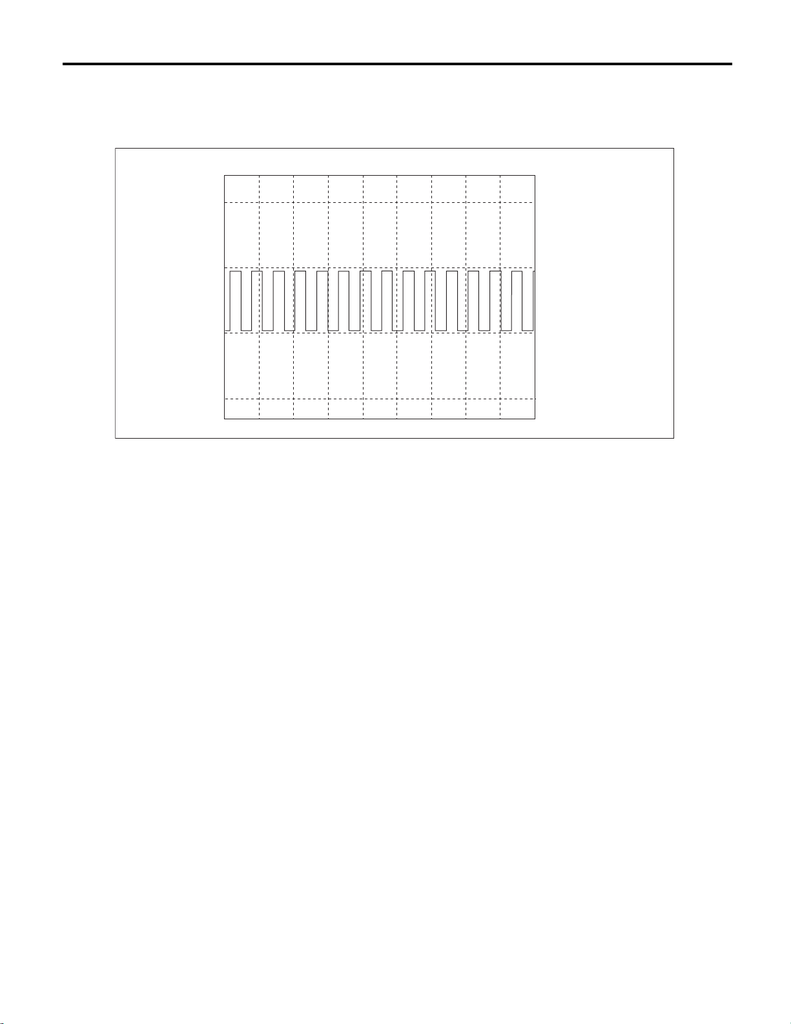

CVT(TR690)-101

Secondary Speed Sensor

CONTINUOUSLY VARIABLE TRANSMISSION

4) Start and warm up the engine.

5) Check the waveform of secondary speed sensor with engine idling.

NOTE:

The waveform cycle changes as the speed changes.

AT-08035

0

5

-5

10

(V)